# problem_set_5_answer_key

Jonathan Pedroza PhD

9/27/2021

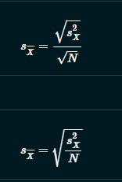

# Hand Calculations

```r
set.seed(09282021)

values = rnorm(10, mean = 21, sd = 4.7)

values
```

```
##  [1] 24.46518 24.87911 27.42912 18.65325 25.87302 34.38246 19.40068 20.13757
##  [9] 19.92043 22.30778
```

You are interested in the amount of hot dogs a competitive eater can eat in 10 minutes. You have a sample of 10 individuals from a local competitive eating group and the amount of hot dogs that they can eat in 10 minutes. From Nathan’s Hot Dog Eating Contest records, you know that every competitive eater has a log of the amount of hot dogs they can eat in a 10 minute span, with the average being 18 hot dogs. You are now interested in knowing whether your sample of competitive eaters can eat significantly less or more hot dogs than everyone in Nathan’s records. Answer all the steps comparing your sample to the population.

1. Create your null and research/alternative hypotheses (in words)

H0: There is no difference in the amount of hot dogs eaten in a 10-minute span between our sample and the population.

H1: Our sample will eat more or less hot dogs in a 10-minute span compared to the population.

2. Select an alpha

The alpha I set was .05 or 5%.

3. Check assumptions

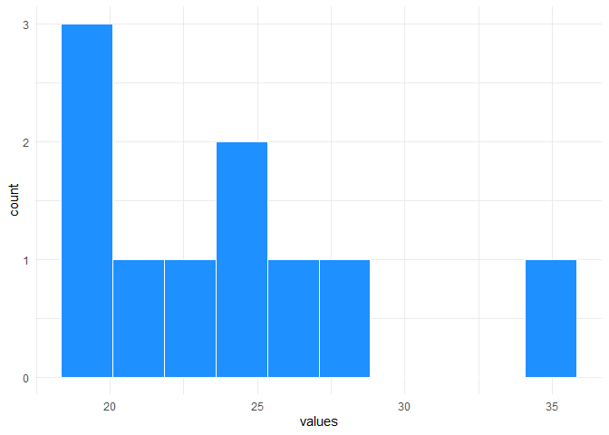

```r
value_df <- data.frame(values)

value_df %>%
  ggplot(aes(values)) +
  geom_histogram(color = "white", fill = "dodgerblue", bins = 10) +
  theme_minimal()
```

```r
shapiro.test(value_df$values)
```

```
##
##  Shapiro-Wilk normality test
##
## data:  value_df$values
## W = 0.89237, p-value = 0.1803
```

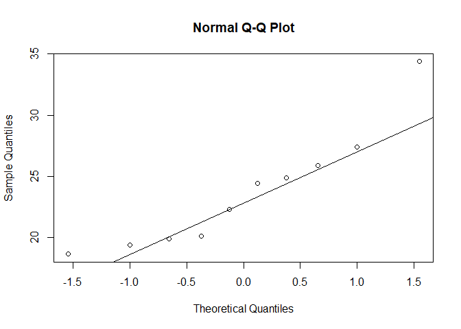

```r
qqnorm(value_df$values)
qqline(value_df$values)
```

4. Get the sample size

Sample size is 10

5. Get the population mean

Population mean was given and is 18 hot dogs

6. Calculate the sample mean

$$\overline{X} = \frac{\Sigma X}{N}$$

```r
round(values, 2)
```

```
##  [1] 24.47 24.88 27.43 18.65 25.87 34.38 19.40 20.14 19.92 22.31
```

```r
24.47+24.88+27.43+18.65+25.87+34.38+19.40+20.14+19.92+22.31
```

```
## [1] 237.45
```

$$\overline{X} = \frac{237.45}{10}$$

```r
237.45/10
```

```
## [1] 23.745
```

The sample mean is 23.75

7. Calculate the variance/standard deviation (SD)

$$S^2_{x} = \frac{\Sigma X^2 - \frac{(\Sigma X)^2}{N}}{N - 1}$$

$$S^2_{x} = \frac{\Sigma X^2 - \frac{(237.45)^2}{10}}{10 - 1}$$

```r
24.47^2+24.88^2+27.43^2+18.65^2+25.87^2+34.38^2+19.40^2+20.14^2+19.92^2+22.31^2
```

```
## [1] 5845.786
```

```r
237.45^2
```

```
## [1] 56382.5
```

$$S^2_{x} = \frac{5845.79 - \frac{56382.5}{10}}{10 - 1}$$

```r
56382.5/10
```

```
## [1] 5638.25
```

$$S^2_{x} = \frac{5845.79 - 5638.25}{9}$$

```r
5845.79 - 5638.25
```

```
## [1] 207.54
```

```r
207.54/9
```

```
## [1] 23.06
```

```r
sqrt(23.06)
```

```
## [1] 4.802083
```

$$S^2_{x} = 23.06$$

$$S_{x} = 4.80$$

The estimated variance is 23.06 and the estimated standard deviation is 4.80.

8. Calculate the estimated standard error (SE)

$$S_{\overline{X}} = \sqrt{\frac{S^2_{x}}{N}}$$

$$S_{\overline{X}} = \sqrt{\frac{23.06}{10}}$$

```r
23.06/10
```

```
## [1] 2.306
```

$$S_{\overline{X}} = \sqrt{2.31}$$

```r
sqrt(2.31)
```

```
## [1] 1.519868
```

$$S_{\overline{X}} = 1.52$$
The standard error of the mean is 1.52.

9. Calculate degrees of freedom (df)

$$df = N - 1$$

```r
10 - 1
```

```
## [1] 9
```

$$df = 9$$

The df is 9.

10. Calculate your t obtained value

$$t_{obt} = \frac{\overline{X} - \mu}{S_{\overline{X}}}$$

$$t_{obt} = \frac{23.75 - 18}{1.52}$$

```r
23.75 - 18
```

```
## [1] 5.75
```

$$t_{obt} = \frac{5.75}{1.52}$$

```r
5.75/1.52
```

```
## [1] 3.782895
```

$$t_{obt} = 3.78$$

11. Compare t-value to t-critical value (use t-table)

Therefore 3.78 > 1.83

12. Check to see what hypothesis you should retain/reject

Reject the null hypothesis. Retain the alternative hypothesis.

13. Calculate the confidence intervals

$$(s_{\overline{x}})(-t_{crit}) + \overline{X} \; \leq \; \mu \; \leq \; (s_{\overline{x}})(t_{crit}) + \overline{X}$$

Lower:
$$(s_{\overline{x}})(-t_{crit}) + \overline{X}$$

$$(1.52)(-1.83) + 23.75$$

```r
(1.52)*(-1.83)
```

```
## [1] -2.7816
```

$$-2.78 + 23.75$$

```r
-2.78 + 23.75
```

```
## [1] 20.97
```

$$Lower\;CI = 20.97$$

Upper:
$$(s_{\overline{x}})(t_{crit}) + \overline{X}$$

$$(1.52)(1.83) + 23.75$$

```r
(1.52)*(1.83)
```

```
## [1] 2.7816
```

$$2.78 + 23.75$$

```r
2.78 + 23.75
```

```
## [1] 26.53
```

$$Upper\;CI = 26.53$$

95% confidence intervals are 20.97 and 26.53

We are 95% confident that the true value of the average hot dogs eaten in a 10-minute span for our sample was between 20.97 and 26.53 hot dogs.

14. Write up report on statistical significance.

A one-sample t-test was conducted comparing our sample of competitive eaters to a population of Nathan’s Hot Dog Eating Contest records of the amount of hot dogs eaten in a 10-minute span. A statistically significant difference was found in the average amount of hot dogs eaten in a 10-minute span. Our sample (*M = 23.75,* SD* = 4.80) eat significantly more hot dogs in the 10-minute span when compared to the population (*M* = 18); t(9) = 3.78, *p* < .05, 95% CI [20.97, 26.53].

# SPSS Calculations

You are interested in the average amount of time college students spend checking their emails according to the MTUAS scale. You have a sample of 372 college students from a local state university. You know all the students that have stated the amount of time they spend checking their emails is on average about 6.5 on the MTUAS scale. You are interested in whether or not your sample of college students is significantly different from the rest of the students in the amount of time they spend checking their emails according to the MTUAS. Answer all the steps comparing your sample to the population in SPSS.

1. Create your null and research/alternative hypotheses (in words)

```r
jp <- rio::import(here::here("jp_thesis_1.sav")) %>%
  janitor::clean_names() %>%
  rowid_to_column() %>%
  mutate(email_avg = (mtuas_email_q1 + mtuas_email_q2 + mtuas_email_q3 + mtuas_email_q4)/4)
```

H0: There will be no differences between our sample of college students and all the students that have taken the MTUAS.
$$H_0: \mu = 6.5$$

H1: Our sample will spend more or less time checking their email compared to all the students that have taken the MTUAS.
$$H_1: \mu \neq 6.5$$

2. Select an alpha

The alpha I set was .05 or 5%.

3. Check assumptions

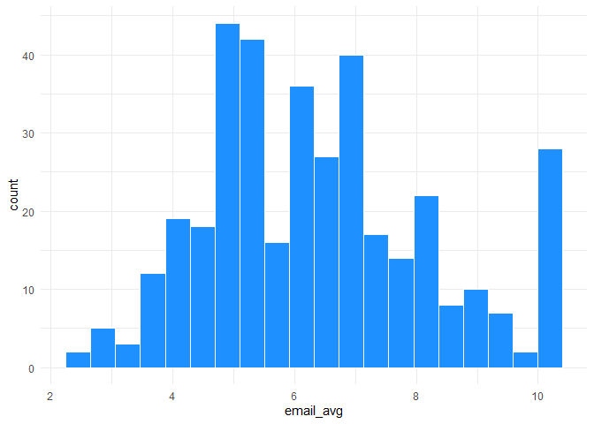

```r
jp %>%
  ggplot(aes(email_avg)) +
  geom_histogram(fill = "dodgerblue", color = "white", bins = 20) +
  theme_minimal()
```

```r
shapiro.test(jp$email_avg)
```

```
##
##  Shapiro-Wilk normality test
##
## data:  jp$email_avg
## W = 0.96654, p-value = 1.595e-07
```

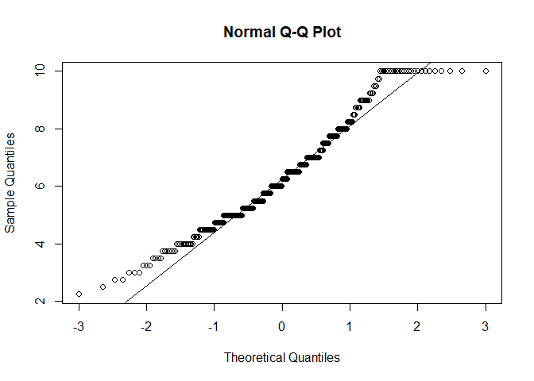

```r
qqnorm(jp$email_avg)
qqline(jp$email_avg)
```

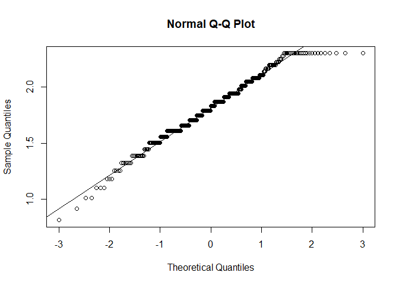

```r
jp <- jp %>%
  mutate(log_email = log(email_avg))

qqnorm(jp$log_email)
qqline(jp$log_email)
```

4. Get the sample size

```r
jp %>%
  count()
```

```
##     n
## 1 372
```

5. Get the population mean

The population mean is 6.5 on the MTUAS email subscale.

6. Calculate the sample mean

```r
psych::describe(jp$email_avg, na.rm = TRUE)["mean"]
```

```
##    mean
## X1 6.38
```

```r
psych::describe(jp$log_email, na.rm = TRUE)["mean"]
```

```
##    mean
## X1 1.81
```

The sample mean is 6.38.

7. Calculate the variance/standard deviation (SD)

```r
psych::describe(jp$email_avg, na.rm = TRUE)["sd"]
```

```
##     sd
## X1 1.8
```

```r
1.8^2
```

```
## [1] 3.24
```

```r
psych::describe(jp$log_email, na.rm = TRUE)["sd"]
```

```
##      sd
## X1 0.29
```

```r
.29^2
```

```
## [1] 0.0841
```

The SD is 1.8 and the variance is 3.24.

8. Calculate the estimated standard error (SE)

```r
psych::describe(jp$email_avg, na.rm = TRUE)["se"]
```

```
##      se
## X1 0.09
```

```r
psych::describe(jp$log_email, na.rm = TRUE)["se"]
```

```
##      se
## X1 0.02
```

The SE is 0.09.

9. Calculate degrees of freedom (df)

```r
372 - 1
```

```
## [1] 371
```

The df is 371.

10. Calculate your t obtained value

```r
t.test(jp$email_avg, mu = 6.5)
```

```
##
##  One Sample t-test
##
## data:  jp$email_avg
## t = -1.2868, df = 371, p-value = 0.199
## alternative hypothesis: true mean is not equal to 6.5
## 95 percent confidence interval:
##  6.195885 6.563524
## sample estimates:
## mean of x
##  6.379704
```

```r
t.test(jp$log_email, mu = 6.5)
```

```
##
##  One Sample t-test
##
## data:  jp$log_email
## t = -310.41, df = 371, p-value < 2.2e-16
## alternative hypothesis: true mean is not equal to 6.5
## 95 percent confidence interval:
##  1.782407 1.841800
## sample estimates:
## mean of x
##  1.812104
```

-1.29 t-obtained value.

11. Compare t-value to t-critical value (use t-table)

12. Check to see what hypothesis you should retain/reject

Retain the null hypothesis.

13. Calculate the confidence intervals

No need. The finding is not statistically significant.

14. Write up report on statistical significance.

There was no difference between our sample of college students and all students that have taken the MTUAS email subscale. The one-sample t-test supports that there is no evidence of a statistically significance difference between the sample and the population; t(371) = -1.29, *p* = .199.

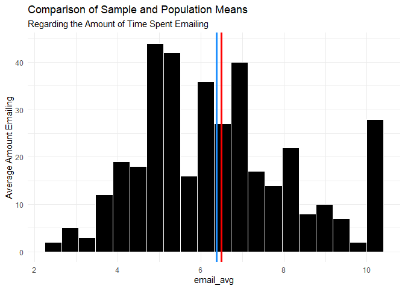

```r
jp %>%
  ggplot(aes(email_avg)) +
  geom_histogram(fill = "black", color = "white", bins = 20) +
  geom_vline(xintercept = 6.5, color = "red", size = 1.25) +
  geom_vline(xintercept = 6.38, color = "dodgerblue", size = 1.25) +
  labs(y = "Average Amount Emailing",
       title = "Comparison of Sample and Population Means",
       subtitle = "Regarding the Amount of Time Spent Emailing") +
    theme_minimal()
```

```r
qt(p = .05/2, df = 371, lower.tail = FALSE)
```

```
## [1] 1.966379
```

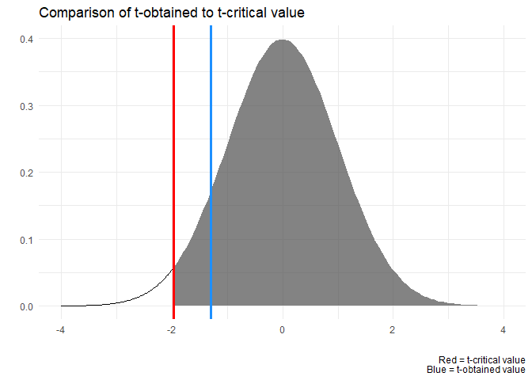

```r
t_dist <- c(-2, 0, 2)

ggplot(data = data.frame(x = c(-4, 4)), aes(x)) +
  stat_function(fun = dnorm,
                geom = "area",
                fill = "gray30", alpha = .7,
                # args = list(mean = 0, sd = 1.5)
                xlim = c(-1.97, 4)) +
  stat_function(fun = dnorm,
                geom = "line",
                xlim = c(-4, -1.97)) +
  geom_vline(xintercept = -1.97, color = "red", size = 1.25) +
  geom_vline(xintercept = -1.29, color = "dodgerblue", size = 1.25) +
  labs(x = "",
       y = "",
       title = "Comparison of t-obtained to t-critical value",
       caption = "Red = t-critical value
       Blue = t-obtained value") +
  theme_minimal()
```